# STAS 215 Homework 1

Winter 2024

Due: Jan 24 11:59pm

# Contents

## Instructions

In this take home assignment you will practice stochastic modeling and generating useful graphics.

You should write your answers in either an `Rmd` (R markdown) or a `qmd` (quarto) document, then compile it into an output report (either a `.pdf` or `.html` file format) for submission in canvas by uploading both the `Rmd` and the `html` or `pdf` files, please call your files `sunetid_HW1.pdf` where `sunetid` is replaced by yours.

In order to run the Rmd file you will need to install BiocStyle package from Bioconductor, you can do so by running the following command in R (you only need to install it once):

```r
BiocManager::install("BiocStyle")
```

The assignment will be graded based on the correctness of your answers, the quality of your explanations and the aesthetics of your plots, the readability of your code and the documentation of your use of chatGPT.

Feel free to work on this assignment during the Labs/ Office hours (you can also ask for help from the TA during this time if you have trouble understanding some of the questions).

Please use `ggplot2` for plotting when possible as these will look better. When using `ChatGPT` please provide the prompt you use and comment on the answer, 5 bonus points if you document a mistake it makes (limited to 2 mistakes).

# 1 Gambler’s Ruin

Consider a gambler who has an initial stake of $60, and repeatedly bets $1 on a game for which the probability of winning is $p$ and the probability of losing is $1-p$. Assume that the gambler decides to stop when their fortune reaches $100 or drops to 0, whichever comes first.

**(a)** Simulate a stochastic process of the gambler’s fortune, with $p=0.5$. Plot the gambler’s fortune against time. *Hint: You can do so by adjusting the script of **gamblersruin.R**. The function can be found with the help of Copilot.*

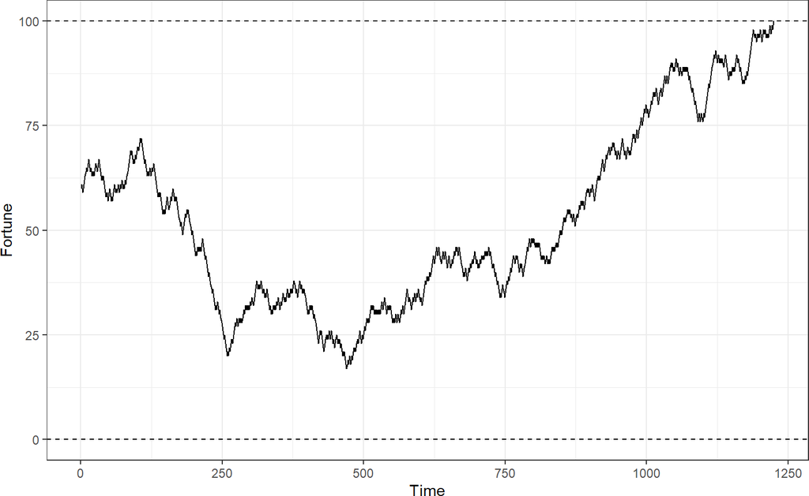

```r
library(ggplot2)
p = 0.5
fortune = 60
bet = 1
upper_stop = 100
lower_stop = 0

gambler_sim <- function (p, fortune, bet, upper_stop, lower_stop, return_vect=T) {
  fortune_vec = c(fortune)
  while (fortune < upper_stop && fortune > lower_stop) {
    fortune = fortune + sample(c(-bet, bet), size = 1, prob = c(1 - p, p))
    if (return_vect) {
      fortune_vec = c(fortune_vec, fortune)
    }
  }
  if (return_vect) {
    return(fortune_vec)
  } else {
    return(fortune == upper_stop)
  }
}

set.seed(1809)
one_game <- gambler_sim(p, fortune, bet, upper_stop, lower_stop)
#ggplot
ggplot(data.frame(one_game), aes(x = seq_along(one_game), y = one_game)) +
  geom_line() +
  geom_hline(yintercept = c(upper_stop, lower_stop), linetype = "dashed") +
  labs(x = "Time", y = "Fortune") +
  theme_bw()
```

**(b)** Under the setting of (a), simulate the probability the gambler wins $100 before losing everything.

```r
set.seed(1809)
N = 1000
#simulate N times
sim <- replicate(N, gambler_sim(p, fortune, bet, upper_stop, lower_stop, return_vect = F))
#probability of winning
mean(sim)
```

```
## [1] 0.598
```

**(c)** Now instead assume $p=0.55$, simulate the probability the gambler wins $100 before losing everything.

```r
set.seed(1809)
N = 1000
#simulate N times
sim <- replicate(N, gambler_sim(p=0.55, fortune, bet, upper_stop, lower_stop, return_vect = F))
#probability of winning
mean(sim)
```

```
## [1] 1
```

# 2 Monte Carlo Method

The time until a bus arrives has an exponential distribution with mean 30 minutes. We will see later in this course that this is essentially a Poisson Process.

**(a)** Draw 1000 samples from the distribution.

```r
set.seed(1809)
# draw 1000 samples from exponential distribution with mean = 30
samples <- rexp(1000, rate = 1/30)
```

**(b)** Simulate the probability that the bus arrives in the first 20 minutes.

```r
# probability that the bus arrives in the first 20 minutes
mean(samples <= 20)
```

```
## [1] 0.476
```

**(c)** Compare with the exact probability that the bus arrives in the first 20 minutes. *Hint: You can do so by using the command `pexp()`.*

```r
# exact probability that the bus arrives in the first 20 minutes
pexp(20, rate = 1/30)
```

```
## [1] 0.4865829
```

# 3 Model Genetic Mutations

Consider a 1,000-long gene sequence, where genetic mutations can be modeled as a random variable taking value in $\{0,1\}$.

**(a)** Generate 1,000 random 0-1 variables that model mutations occurring along the gene sequence. These occur independently at a rate of $10^{-4}$ each. *Hint: Relate this case to the arrival of bus example in Problem 2.*

```r
set.seed(1809)
samples <- rbinom(1000, size = 1, prob = 10^(-4))
```

**(b)** Then the sum of the 1,000 positions is a count of how many mutations have happened in sequences of length 1,000. Take a guess of the distribution for these mutation sums, verify your guess by using a goodness of fit test and make a plot to visualize the quality of the fit.

```r
library("vcd")
```

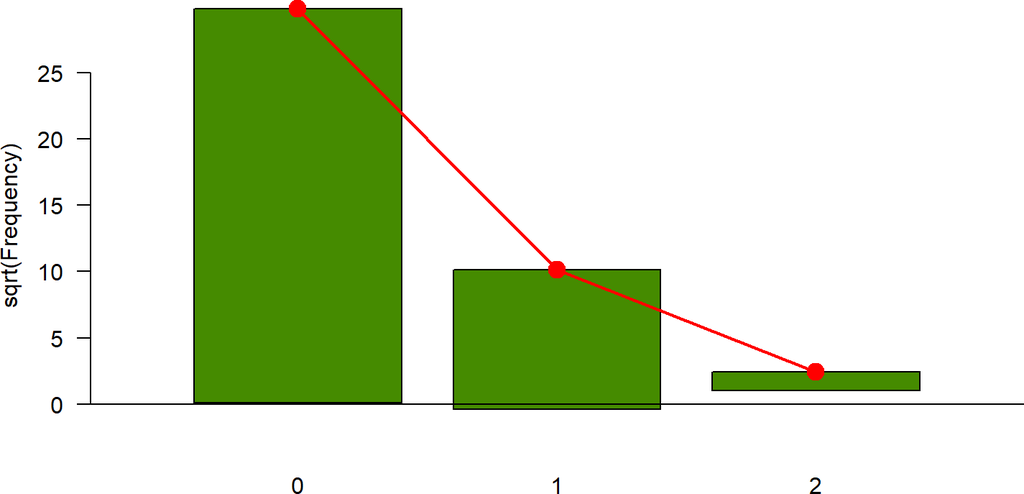

```r
N = 1000
sum_mutations <- replicate(N, sum(rbinom(1000, size = 1, prob = 10^(-4))))
gf1 = goodfit(sum_mutations, "poisson")
rootogram(gf1, xlab = "", rect_gp = gpar(fill = "chartreuse4"))
```

# 4 Sequence Analysis for DNA

In Lab 0, you have already come up with a nice transition graph of the four DNA bases, i.e., A, C, G, T.

**(a)** Now add transition probability of your choice to each edge. Note that they have to satisfy certain conditions in order to be valid.

**(b)** Write out the associate transition matrix of your graph. Sanity check that your transition matrix also satisfies the conditions in (a).

**(c)** Does there seem to be an absorbing state in your transition matrix? Is it reasonable for a DNA sequence? *Hint: You can do so by taking high matrix powers.*

No absrobing state in the transition matrix, which is reasonable for a DNA sequence. (A != T and G!= C means that the sequence is stranded)

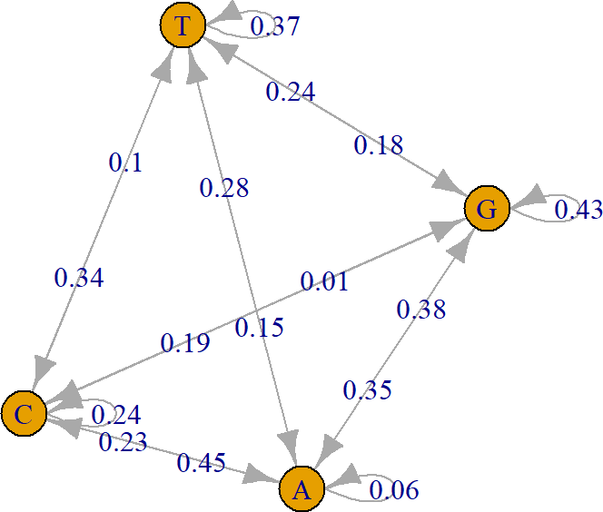

```r
library(igraph)
library(expm)
# Copy from Lab 0
set.seed(1234)
# generate random transition matrix 4x4 with each row summing to 1
transition_matrix <- matrix(runif(16), nrow=4, ncol=4)
transition_matrix <- transition_matrix/rowSums(transition_matrix)
#convert transition matrix to table with columns A , C, G, T
colnames(transition_matrix) <- c("A", "C", "G", "T")
rownames(transition_matrix) <- c("A", "C", "G", "T")
#plot a graph of transition matrix above with directed edges
g <- graph.adjacency(transition_matrix, mode="directed", weighted=TRUE)
plot(g, edge.label=round(E(g)$weight, 2), vertex.size=20, layout=layout.fruchterman.reingold)
```

```r
#taking high matrix powers
transition_matrix %^% 100
```

```
##           A         C         G         T
## A 0.2477515 0.1819758 0.3196355 0.2506372
## C 0.2477515 0.1819758 0.3196355 0.2506372
## G 0.2477515 0.1819758 0.3196355 0.2506372
## T 0.2477515 0.1819758 0.3196355 0.2506372
```

# 5 Maximum Likelihood Estimator

We saw the maximum likelihood procedures in class when we estimated the transition probabilities in CpG islands, now let’s practice how to come up with a maximum likelihood estimator.

**(a)** Write a function that generates random uniform numbers between $0$ and $7$, and then returns their maximum.

```r
library(purrr)
max_unif <- function(n, maxi) {
  max(purrr::rdunif(n, 0, maxi))
}
```

**(b)** Execute the function for $n=25$, repeat this procedure $B=1000$ times. Plot the empirical distribution of these $1000$ maxima.

```r
set.seed(1809)
B = 1000
maxima <- replicate(B, max_unif(25, 7))
```

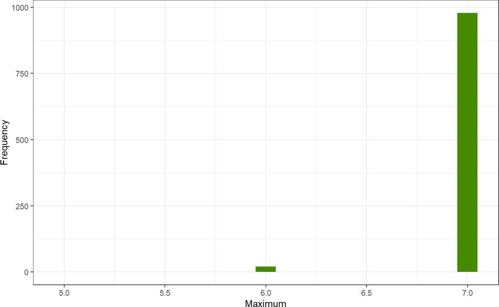

```r
maxima_df <- data.frame(maxima)
ggplot(maxima_df, aes(x = maxima)) +
  geom_histogram(binwidth = 0.1, fill = "chartreuse4") +
  labs(x = "Maximum", y = "Frequency") +
  theme_bw()
```

**(c)** What is the maximum likelihood estimator of the maximum of a sample of size 25 (call it $\widehat{\theta}$)? Give an intuitive justification of the maximum likelihood estimator.

```r
# array of theta form 1 to 10
theta <- seq(1, 10, 1)
llh <- function(x, theta) {
  pmf = replicate(B, max_unif(25, theta))
  #calculate log likelihood based on probability mass function
  log_llh = 0
  for (i in x) {
    prob = sum(pmf == i)/length(pmf)
    log_llh = log_llh + log(prob)
  }
  return (log_llh)
}
# loop through x in maxima and theta in theta
for (t in theta) {
  print(c(t ,llh(maxima, t)))
}
```

```
## [1]    1 -Inf
## [1]    2 -Inf
## [1]    3 -Inf
## [1]    4 -Inf
## [1]    5 -Inf
## [1]    6 -Inf
## [1]    7.0000 -113.9121
## [1]    8 -Inf
## [1]    9 -Inf
## [1]   10 -Inf
```

MLE = 7

Do the same but for continuous uniform distribution and use kernel density to estimate the density function of the empirical distribution of the maxima.

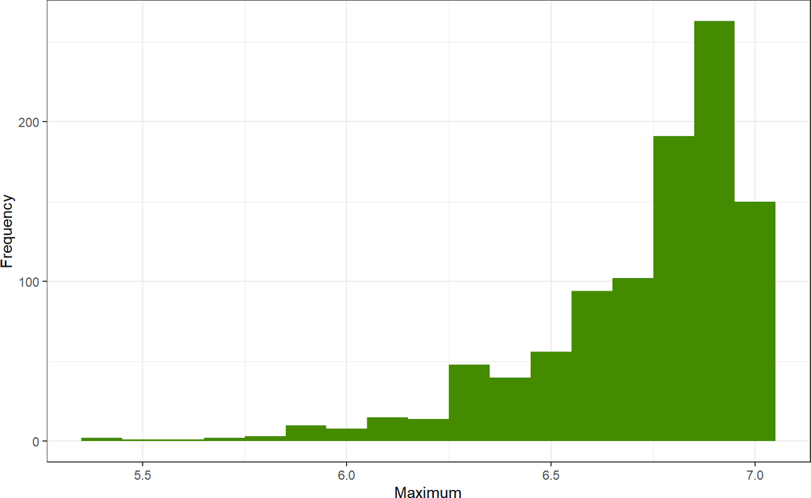

```r
set.seed(1809)
B = 1000
max_unif <- function(n, maxi) {
  max(runif(n, min = 0, max = maxi))
}
maxima <- replicate(B, max_unif(25, 7))
maxima_df <- data.frame(maxima)
ggplot(maxima_df, aes(x = maxima)) +
  geom_histogram(binwidth = 0.1, fill = "chartreuse4") +
  labs(x = "Maximum", y = "Frequency") +
  theme_bw()
```

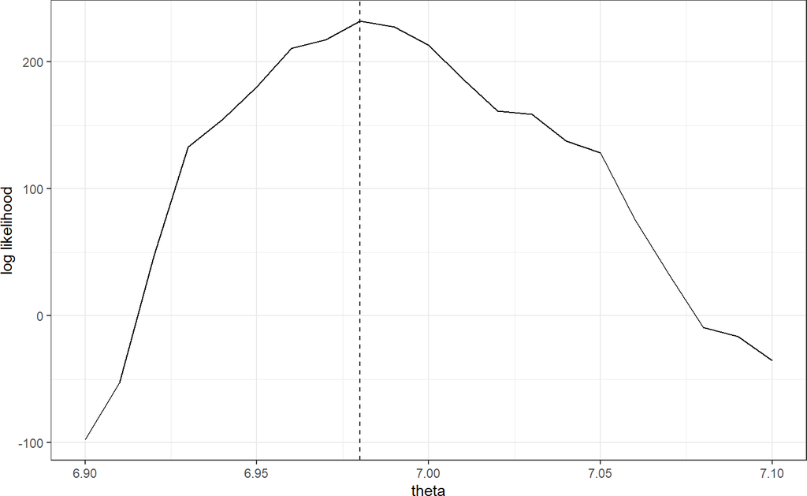

```r
theta <- seq(6.9, 7.1, 0.01)
llh <- function(x, theta) {
  pdf = density(replicate(B, max_unif(25, theta)))
  #calculate log likelihood based on probability mass function
  log_llh = 0
  for (i in x) {
    # get pdf$x closest to i

    prob = pdf$y[(which(abs(pdf$x - i)==min(abs(pdf$x - i))))]
    log_llh = log_llh + log(prob)
  }
  return (log_llh)
}

# loop through x in maxima and theta in theta
log_llhs = c()
for (t in theta) {
  log_llhs = c(log_llhs, llh(maxima, t))
}

#convert to ggplot and label maximum likelihood with number
ggplot(data.frame(theta, log_llhs), aes(x = theta, y = log_llhs)) +
  geom_line() +
  geom_vline(xintercept = theta[which.max(log_llhs)], linetype = "dashed") +
  labs(x = "theta", y = "log likelihood") +
  theme_bw()
```

```r
theta[which.max(log_llhs)]
```

```
## [1] 6.98
```

MLE = 6.98

# 6 Three examples

Give three examples of Hidden Markov Models in Biology. Do not use examples that involve sequence analysis, but provide three the references to papers that use HMMs in biology and that provide software that enables the reproduction of their results. (Bioconductor or CRAN packages are preferred.)

1. HMM for animal movement  
   https://cran.r-project.org/web/packages/moveHMM/vignettes/moveHMM-guide.pdf
2. Chromatin Segmentation Analysis (Predict Chromatin State)  
   https://bioconductor.org/packages/release/bioc/html/segmenter.html
3. Character Evolution  
   https://cran.r-project.org/web/packages/corHMM/corHMM.pdf